# APD report

Template for data reading and cleaning from the ANZICS APD

Lewis Campbell

2021-03-08

# Introduction

The ANZICS APD is a registry covering every adult patient admitted to the majority of Intensive Care Units in Australia. We contributed to the benchmarking of illness and treatment in the [Northern Territory](https://www.nt.gov.au) by entering every patient into this database. Using the statistical programming environment `R` with the `RStudio` IDE, we are able to perform sophisticated anylses. This analysis was run on 2021-03-08. We start with an introduction describing the total patient cohort over the period 2020-01-01 to 2021-01-08. Later sections answer the question, “what is the need and feasibility for an ECMO service at Royal Darwin Hospital?”.

The explanation and supporting materials are available from [ANZICS](https://www.anzics.com.au/anzics-registries).

## Numbers of patients

Over the period there were 1059 admissions, of 930 individuals. The weekly admission rate is shown below, and the instantaneous occupancy, changing at the moment of each admission or discharge, is in the margin.

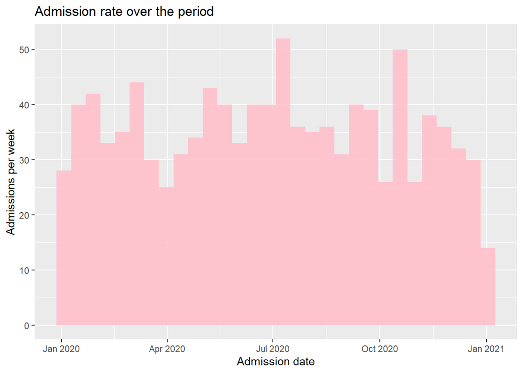

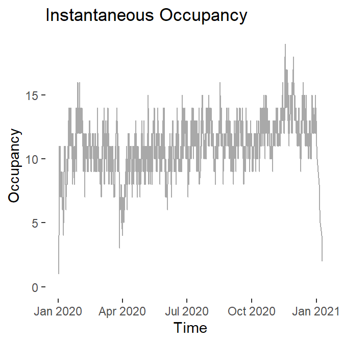

Instantaneous occupancy over the period.

## Intensity weighted occupancy

The admission rate tells part of the story, but sicker patients need more intense care. The severity score on admission tells a little more of the story. Each bar is an individual patient admission. The vertical height of the bars is equal to the predicted risk of death on admission, and the horizontal width is the length of the admission. Transparency is set at 0.1 to allow overlapping bars to be seen. This gives a good qualitative view of how many very sick patients were admitted at a time, or “Intensity weighted bed occupancy”. The rest of the story about treatment intensity can only be told with daily data, which we don’t compile.

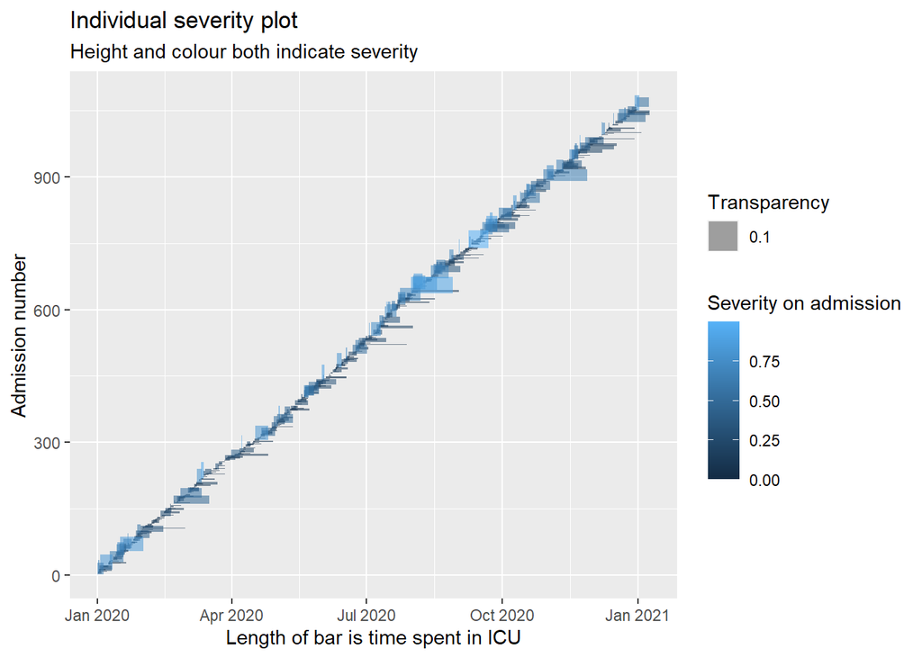

The gaps and overlaps give an idea of when it was busy, and the height and brightness of the bars give an idea of how sick each patient was on admission.

Now the occupancy can be numerically weighted for the admission ANZROD score. This is very simplistic, but gives a granular summary of numbers combined with severity. In the plots below, firstly the occupancy is weighted for the severity of illness of the patients who are occupying the beds. The resulting intensity-weighted occupancy is then plotted over the raw occupancy, balanced so they display the same mean value. Then a locally weighted estimate is applied to show the deterministic portion of the trend over time. In simple language, it smooths the instantaneous data to draw the eye to trends.

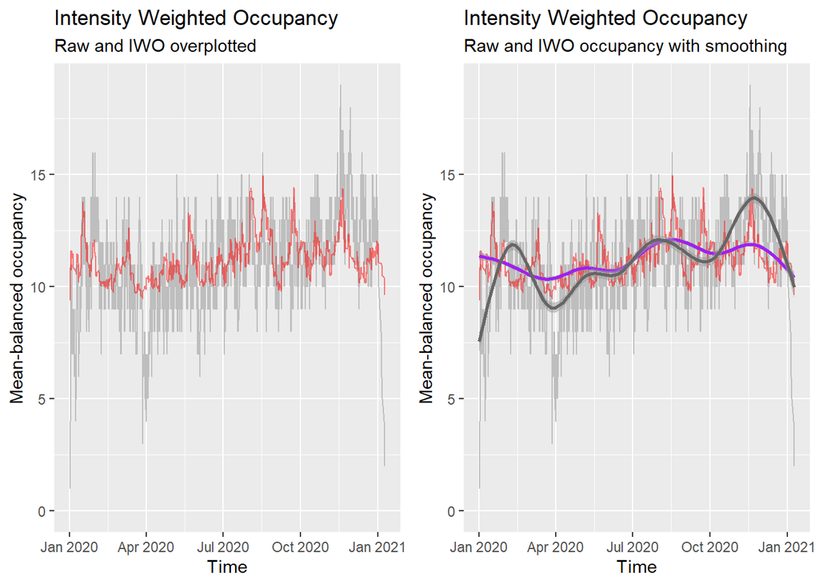

## Discharge after hours

Of the 988 patients who left ICU alive, 203 were discharged out of hours and a further 75 were discharged on a weekend. The table below compares some of their characteristics.

```
## # A tibble: 3 x 5
##   OOHDC       Adm_ANZROD ICULOS Hsp_mortality Post_ICU_LOS
##   <chr>            <dbl>  <dbl>         <dbl>        <dbl>
## 1 After_hours     0.0933   3.30         0.031         7.18
## 2 In_hours        0.0954   3.71         0.018         6.49
## 3 Weekend         0.0609   4.43         0.046         6.19
```

## Data quality

There are many ways to describe missingness. This is a big topic but the basic difference is between entries that are missing at random, and those where the missingness itself represents a process. It’s difficult to tell from a single dataset which is happening, and topic knowledge is needed. We get a report on the data quality of the essential items, but not on the whole dataset. Here is a snapshot of the proportion of missingness in each variable.

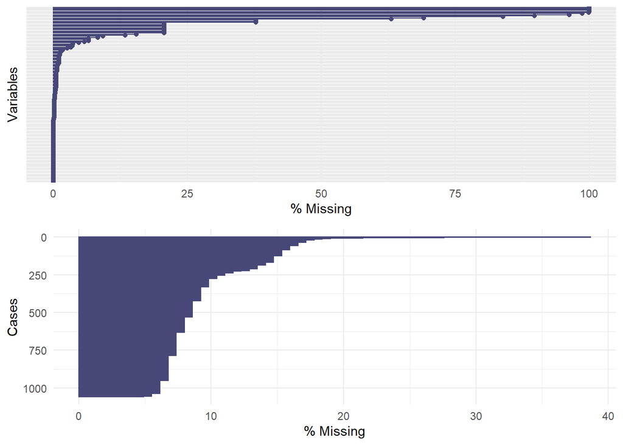

APD variables ordered by proportion missing over the period.

The table below gives further detail on the variables with the greatest proportion of missing data. Many of these are simply not useful. Many are extremely useful, but missed for various reasons.

```
## # A tibble: 163 x 3
##    variable            n_miss pct_miss
##    <chr>                <int>    <dbl>
##  1 EthnicityOther        1059    100
##  2 CABGGraft             1059    100
##  3 CABGRedo              1059    100
##  4 PT_identifier         1059    100
##  5 ICU_identifier        1059    100
##  6 HOSP_identifier       1058     99.9
##  7 AMIThromboTher        1045     98.7
##  8 ReadmissionLagHours   1020     96.3
##  9 TransferredFrom        951     89.8
## 10 TransferredTo          889     83.9
## # ... with 153 more rows
```

In exploring the reasons for missing observations, some plots can help. These are not necessarily what is needed in a monthly report, but the patterns of missingness, as a signal of the underlying mechanisms by which observations are missed, can be very valuable in examining our own practice.

## ANZROD and outcome

This slightly busy plot has another purpose. It repeats the above analysis, and codes the admissions by outcome: those who survived are a shade of blue, and those who died are a shade of red. The lowest risk of death is displayed in the deepest red, to emphasise those patients who went on to die against the prediction of the algorithm, who will appear as **short bright bars**. These outcomes are distressing and often raise the question of whether they could have been prevented.

Short bright red bars suggest an ICU death in a patient with a low predicted mortality and brief ICU stay before death.

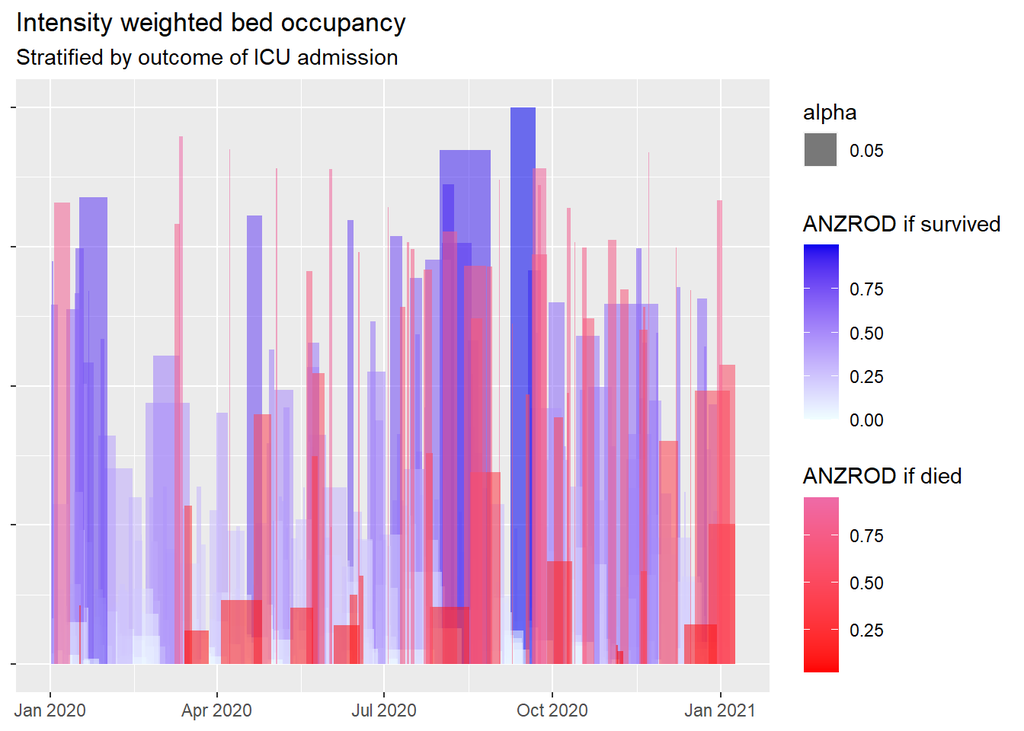

We often only review the predicted risk of death for those who died, because that is the structure of our quality reporting. Over this period, the table below shows the ANZROD-predicted risk of death for those who died was 0.622. As a corrective, it’s important also to review the predicted risk of death in survivors. Across this period the median predicted risk of death in those who actually survived was 0.031, as shown in the table below.

| ICUOutcome | Mean ANZROD |
| --- | --- |
| Died | 0.62 +/- 0.22 |
| Home | 0.02 +/- 0.01 |
| Other | 0.08 +/- 0.07 |
| OtherHospitalIcu | 0.09 +/- 0.14 |
| OtherHospitalNormalWard | 0.02 +/- 0.01 |
| Unknown | 0.01 +/- 0 |
| Ward | 0.03 +/- 0.04 |
| NA | 0.12 +/- 0.06 |

More important again, however, is the outcome in each category of predicted risk. That is listed in the table below (which might have some gaps because of small numbers, depending on the period selected).

[output not shown]

## Subsets of admissions

The count of certain admission diagnoses or clinical features can be shown in the context of all admissions. Here, cardiovascular admissions are displayed. The first code returns the diagnostic category numbers for any diagnoses admitted during the period. Use these to fill in the second bit of code with the diagnostic categories you’re interested in.

```r
#retrieves the categories present in the dataset
levels(as.factor(APD$APACHECategory))
```

```
##  [1] "Cardiovascular (101-111)"         "Cardiovascular (1202-1213)"
##  [3] "Gastrointestinal (1401-1413)"     "Gastrointestinal (301-313)"
##  [5] "Gynaecological (1801-1803)"       "Haematological (801-802)"
##  [7] "Metabolic (2201)"                 "Metabolic (701-704)"
##  [9] "Musculoskeletal/Skin (1101-1102)" "Musculoskeletal/Skin (1902-1904)"
## [11] "Neurological (1501-1506)"         "Neurological (401-410)"
## [13] "Renal/Genitourinary (1701-1705)"  "Renal/Genitourinary (901-903)"
## [15] "Respiratory (1301-1304)"          "Respiratory (201-213)"
## [17] "Sepsis (501-504)"                 "Trauma (1601-1605)"
## [19] "Trauma (601-605)"
```

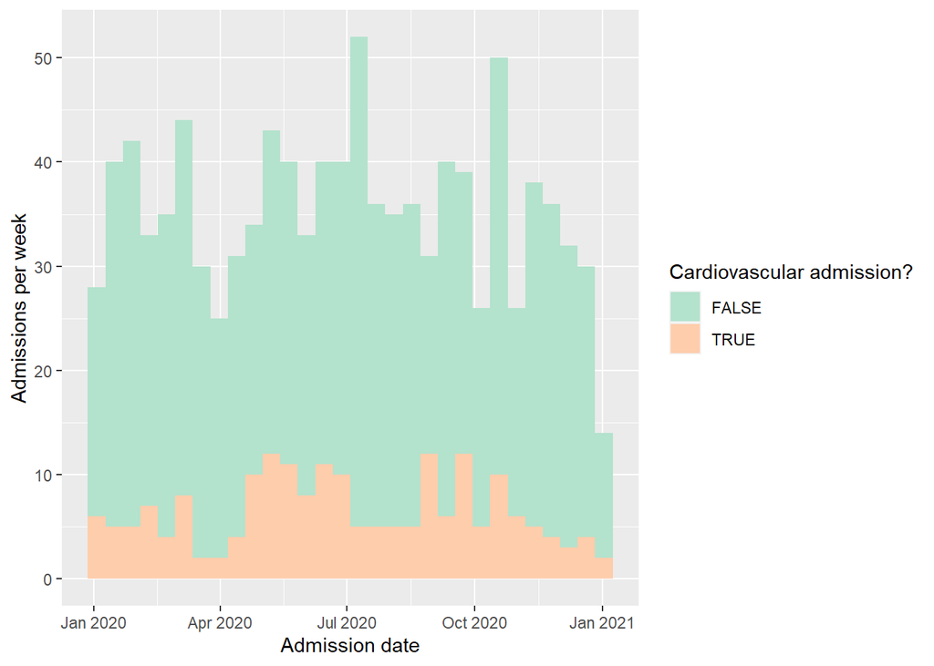

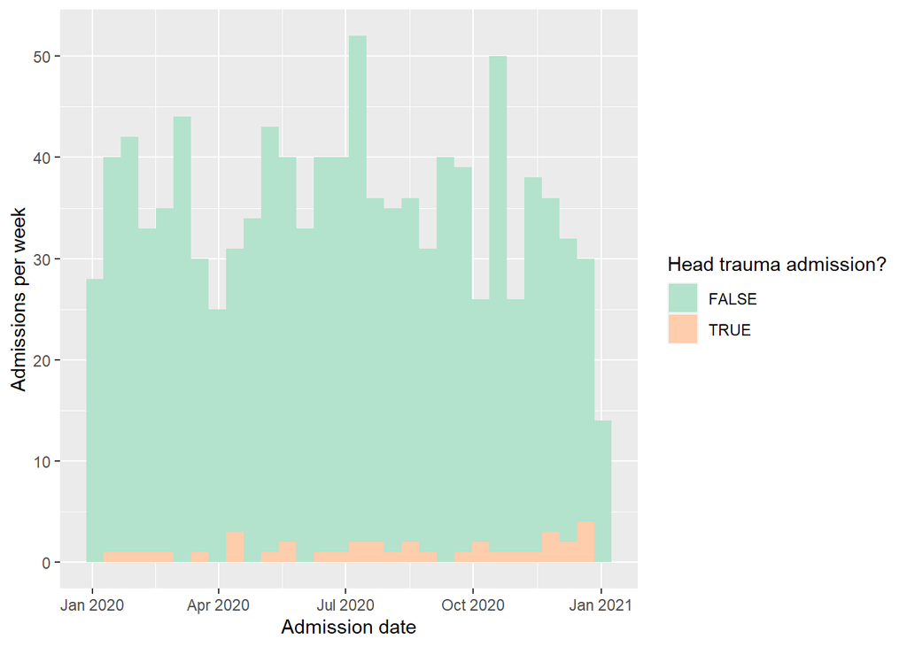

The full admission numbers over the period are also displayed in the table below, with actual ICU mortality and predicted mortality by the ANZROD algorithm.

| APACHECategory | Admissions | Observed Mortality | ANZROD Predicted Mortality |
| --- | --- | --- | --- |
| Cardiovascular (101-111) | 133 | 0.143 | 0.226 |
| Cardiovascular (1202-1213) | 61 | 0.000 | 0.026 |
| Gastrointestinal (1401-1413) | 80 | 0.038 | 0.078 |
| Gastrointestinal (301-313) | 24 | 0.083 | 0.167 |
| Gynaecological (1801-1803) | 18 | 0.000 | 0.004 |
| Haematological (801-802) | 10 | 0.200 | 0.461 |
| Metabolic (2201) | 8 | 0.000 | 0.009 |
| Metabolic (701-704) | 61 | 0.000 | 0.041 |
| Musculoskeletal/Skin (1101-1102) | 4 | 0.000 | 0.088 |
| Musculoskeletal/Skin (1902-1904) | 33 | 0.030 | 0.033 |
| Neurological (1501-1506) | 57 | 0.000 | 0.054 |
| Neurological (401-410) | 89 | 0.124 | 0.185 |
| Renal/Genitourinary (1701-1705) | 17 | 0.000 | 0.025 |
| Renal/Genitourinary (901-903) | 12 | 0.000 | 0.129 |
| Respiratory (1301-1304) | 43 | 0.023 | 0.027 |
| Respiratory (201-213) | 119 | NA | 0.126 |
| Sepsis (501-504) | 157 | 0.108 | 0.187 |
| Trauma (1601-1605) | 38 | NA | 0.078 |
| Trauma (601-605) | 93 | 0.054 | 0.083 |
| NA | 2 | 0.000 | 0.024 |

# Today’s question

**How many patients are likely to benefit from ECMO retrieval?**

This question can’t be directly answered with retrospective data. There may be patients who survived but with impairments that could have been prevented with more aggressively lung protective ventilation. There may be patients who were considered unsalvageable and were not even referred for consideration of ICU. There may be patients who are listed with one top line diagnosis but who also had a condition amenable to mechanical circulatory or ventilatory support. Registry data is unreliable on the inclusions and exclusions which pertain at the moment of considering referral.

As a starting point, we chose set of criteria which reflect the experience of ELSO sites, before further limiting the criteria to those patients with a high predicted benefit *if their registry entries reflect their determinative parameters*. The latter number places a lower limit on the possible referrals: 1 For VV ECMO: - Worst P:F ratio <100 mmHg / atm while invasively ventilated - Died in ICU OR long stay >7 days - No chronic conditions preventing VV ECMO treatment, and age <=65 2 For VA ECMO: - Cardiovascular admission or cardiac arrest - Inotropes required and highest Systolic BP<90 - Died or transferred to another ICU - No chronic conditions preventing VV ECMO treatment, and age <=65

These result in between 7 and 32 patients for VV ECMO, and between 2 and 12 patients for VA ECMO per year.